# Allometry of Mammalian Breathing Rates

Author

Elliot Stielstra, Ethan Wilstermann, Simon Rylaarsdam, Stacy DeRuiter, Andreas Fahlman

Published

March 19, 2025

# Data Access

Raw data files can be found at:

https://stacyderuiter.github.io/breath-allometry/data/breath-rate-FINAL-clean.csv

https://stacyderuiter.github.io/breath-allometry/data/additional-species.xlsx

The public github repository containing this work is at:

https://github.com/stacyderuiter/breath-allometry

# Analysis

## Context and Goals

The objective with this analysis was to explore the allometric relationship between breathing frequency and body mass for mammals that live in different habitats.

Unlike other studies, We aimed to only use data that were sampled under basal conditions; 1) adult animals, 2) not pregnant or lactating, 3) post-prandial (fasted), 4) at rest, and 5) in their thermoneutral zone. Although, we included animals at different activity levels, the final analysis focused on those that were inactive, so activity level 1. Also, not all animals may have fasted long enough to be post-prandial, like ruminants.

## Data Preparation

```r
breath_data <- read_csv('data/breath-rate-FINAL.csv',
                        show_col_types = FALSE,
                        trim_ws = TRUE,
                        locale = readr::locale(encoding = "latin1"))

#extract the variables of interest
breath_data <- breath_data |>
  select(log_fr, log_Mb, habitat, order, family, genus, species,
         breath_rate, body_mass, sex,
         activity_level, individual_name, common_name, age, temp, location,
         `Thermoneutral range`, `Normal temperature range`) |>
  mutate(across(c(order, family, genus, individual_name),
         function(x) str_replace_all(x, "[^[:alnum:]]", ""))) |>
  mutate(across(c(species, common_name),
         function(x) str_replace_all(x, "[^[:alnum:]]", " "))) |>
  mutate(common_name = ifelse(species == "orca", "Killer Whale", common_name)) |>
  mutate(across(c(individual_name, common_name, habitat, location), str_to_title)) |>
  mutate(common_name = str_replace_all(common_name, pattern = "Harbour", replacement = "Harbor")) |>
  mutate(common_name = str_replace_all(common_name, pattern = "Sabel", replacement = "Sable")) |>
  mutate(common_name = str_replace_all(common_name, pattern = "Giraff", replacement = "Giraffe")) |>
  mutate(common_name = str_replace_all(common_name, pattern = "Giraffee", replacement = "Giraffe")) |>
  mutate(common_name = str_replace_all(common_name, pattern = "Asiatisk", replacement = "Asian")) |>
  mutate(common_name = ifelse(common_name == "Brown Fur Seal", "South African Fur Seal", common_name)) |>
  mutate(activity_level = factor(activity_level),
         habitat = factor(habitat),
         location = factor(location)) |>
  drop_na(log_fr, log_Mb, habitat, activity_level, temp, location, order, family, genus, species, individual_name)

breath_data <- breath_data |>
  arrange(order, common_name)

write_csv(breath_data, 'data/breath-rate-FINAL-clean.csv')

glimpse(breath_data)
```

```
Rows: 1,240
Columns: 18
$ log_fr                     <dbl> 0.982, 1.079, 1.057, 1.070, 0.871, 1.072, 1…
$ log_Mb                     <dbl> 2.000, 2.000, 2.000, 2.000, 2.041, 2.041, 2…
$ habitat                    <fct> Terrestrial, Terrestrial, Terrestrial, Terr…
$ order                      <chr> "Artiodactyla", "Artiodactyla", "Artiodacty…
$ family                     <chr> "Bovidae", "Bovidae", "Bovidae", "Bovidae",…
$ genus                      <chr> "Addax", "Addax", "Addax", "Addax", "Addax"…
$ species                    <chr> "nasomaculatus", "nasomaculatus", "nasomacu…
$ breath_rate                <dbl> 9.594006, 11.994993, 11.402498, 11.748976, …
$ body_mass                  <dbl> 100.00, 100.00, 100.00, 100.00, 110.00, 110…
$ sex                        <chr> "F", "F", "F", "F", "M", "M", "M", "M", "F"…
$ activity_level             <fct> 1, 1, 1, 1, 1, 2, 2, 2, 1, 1, 1, 1, 1, 1, 2…
$ individual_name            <chr> "Dune", "Dune", "Dune", "Dune", "Leon", "Le…
$ common_name                <chr> "Addax Antelope", "Addax Antelope", "Addax …
$ age                        <dbl> 5, 5, 5, 5, 7, 7, 7, 7, 6, 6, 7, 7, 7, 7, 7…
$ temp                       <dbl> 14.4, 14.4, 14.4, 14.8, 14.4, 14.4, 14.4, 1…
$ location                   <fct> Air, Air, Air, Air, Air, Air, Air, Air, Air…
$ `Thermoneutral range`      <chr> "N/A", "N/A", "N/A", "N/A", "N/A", "N/A", "…
$ `Normal temperature range` <chr> "-4C to 45 C", "-4C to 45 C", "-4C to 45 C"…
```

## Data Exploration

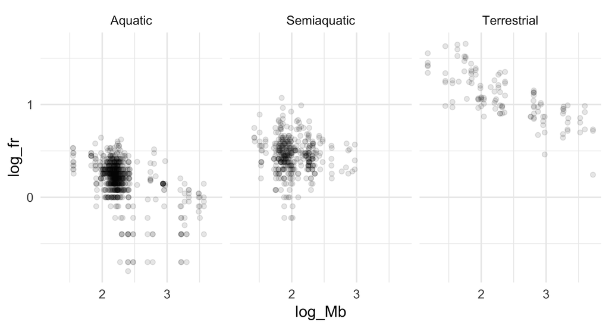

```r
gf_point(log_fr ~ log_Mb | habitat, alpha=0.1, data = breath_data)
```

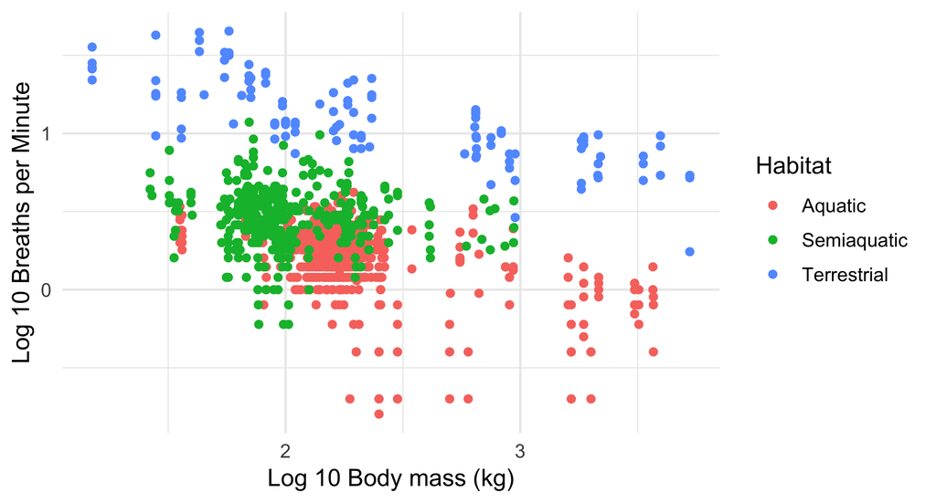

```r
gf_point(log_fr ~ log_Mb, data = breath_data, color= ~habitat)|>
    gf_labs(x = "Log 10 Body mass (kg)",
           y = "Log 10 Breaths per Minute",
           color = "Habitat")
```

## Model Fitting

This model that includes consideration (phylogenetic contrast) of order, genus and species via a set of nested random intercepts, plus a separate random intercept for the individual animal. The model includes body mass, activity, temperature of either water or air (where the animal was measured) and habitat. The model also accounts for differences in slopes (for the body mass effect) for animals of different habitats.

```r
breath_model <- glmmTMB(log_fr ~ log_Mb * habitat + activity_level + temp +  location +
                         (1 | order/family/genus/species) + (1 | individual_name),
                      data = breath_data)
summary(breath_model)
```

```
 Family: gaussian  ( identity )
Formula:
log_fr ~ log_Mb * habitat + activity_level + temp + location +
    (1 | order/family/genus/species) + (1 | individual_name)
Data: breath_data

     AIC      BIC   logLik deviance df.resid
 -1275.1  -1193.1    653.5  -1307.1     1224

Random effects:

Conditional model:
 Groups                     Name        Variance  Std.Dev.
 species:genus:family:order (Intercept) 6.667e-03 0.0816487
 genus:family:order         (Intercept) 2.102e-10 0.0000145
 family:order               (Intercept) 3.747e-04 0.0193580
 order                      (Intercept) 3.753e-02 0.1937319
 individual_name            (Intercept) 6.438e-03 0.0802388
 Residual                               1.519e-02 0.1232402
Number of obs: 1240, groups:
species:genus:family:order, 35; genus:family:order, 30; family:order, 15; order, 6; individual_name, 336

Dispersion estimate for gaussian family (sigma^2): 0.0152

Conditional model:
                            Estimate Std. Error z value Pr(>|z|)
(Intercept)                0.4892483  0.1503306   3.254  0.00114 **
log_Mb                    -0.1138533  0.0436227  -2.610  0.00906 **
habitatSemiaquatic         0.1845857  0.1737416   1.062  0.28805
habitatTerrestrial         1.2993932  0.1892186   6.867 6.55e-12 ***
activity_level2            0.0821225  0.0099591   8.246  < 2e-16 ***
activity_level3            0.1722430  0.0173106   9.950  < 2e-16 ***
temp                      -0.0002266  0.0011415  -0.199  0.84263
locationWater             -0.0674684  0.0240032  -2.811  0.00494 **
log_Mb:habitatSemiaquatic  0.0127359  0.0670137   0.190  0.84927
log_Mb:habitatTerrestrial -0.2011367  0.0742025  -2.711  0.00672 **
---
Signif. codes:  0 '***' 0.001 '**' 0.01 '*' 0.05 '.' 0.1 ' ' 1
```

## Model Assessment

These graphical checks were carried out to confirm that model conditions (linearity, plus constant variance, independence, and normality of residuals) were met.

```r
breath_data <- breath_data |>
  mutate(preds = predict(breath_model),
         resids = resid(breath_model))
```

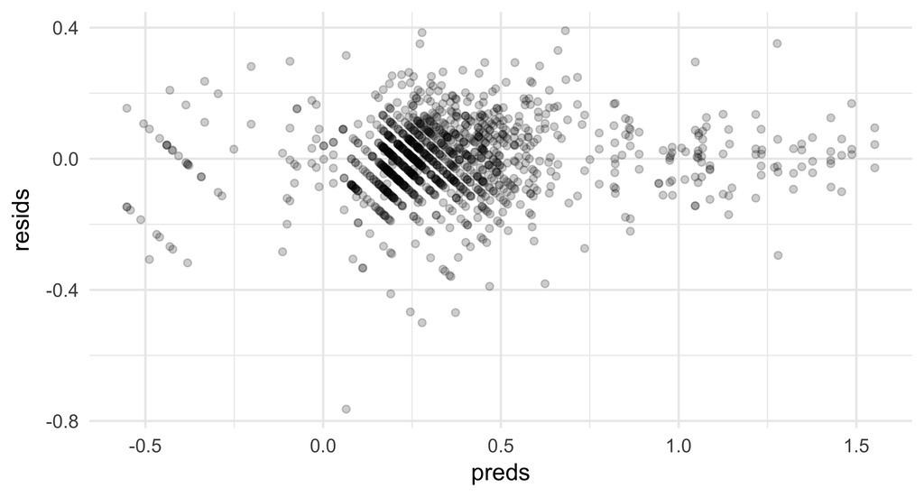

```r
gf_point(resids ~ preds, data = breath_data, alpha = 0.2)
```

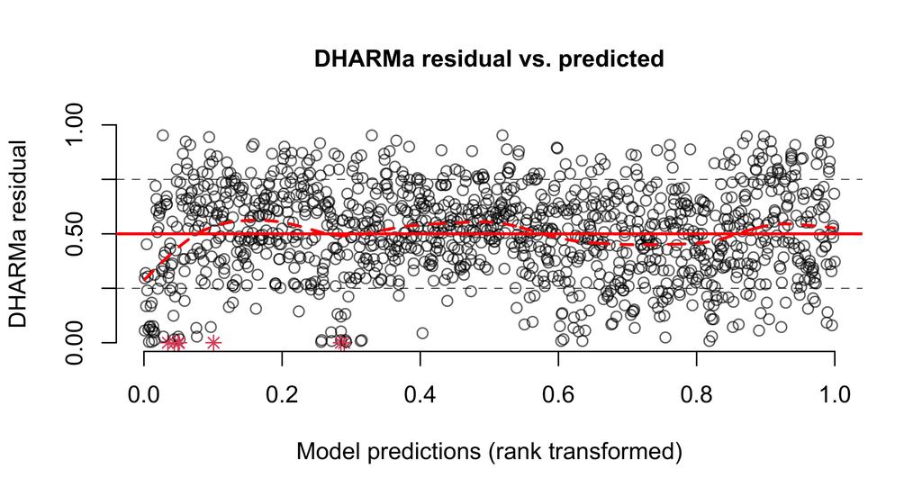

```r
sim_res <- simulateResiduals(breath_model)
plotResiduals(sim_res, quantreg = FALSE)
```

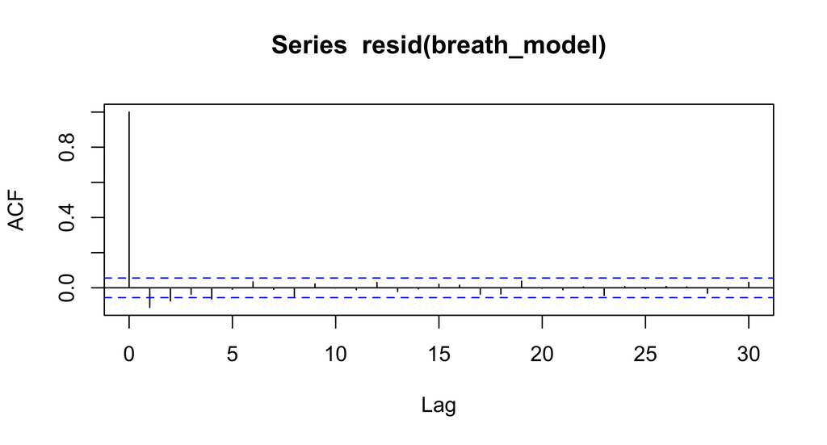

```r
acf(resid(breath_model))
```

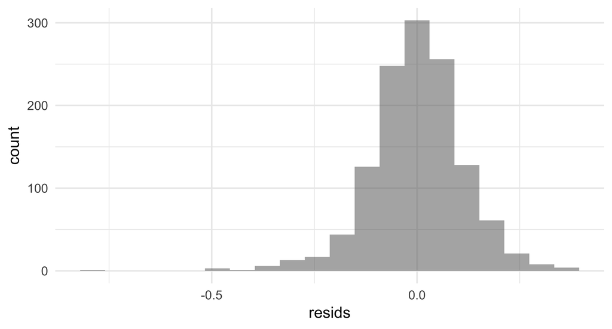

```r
gf_histogram(~resids, data = breath_data, bins = 20)
```

## Inference

```r
car::Anova(breath_model)
```

```
Analysis of Deviance Table (Type II Wald chisquare tests)

Response: log_fr
                  Chisq Df Pr(>Chisq)
log_Mb          29.2187  1  6.465e-08 ***
habitat        201.1108  2  < 2.2e-16 ***
activity_level 120.7595  2  < 2.2e-16 ***
temp             0.0394  1   0.842633
location         7.9006  1   0.004942 **
log_Mb:habitat   9.1197  2   0.010464 *
---
Signif. codes:  0 '***' 0.001 '**' 0.01 '*' 0.05 '.' 0.1 ' ' 1
```

The ANOVA output shows a strong evidence of association between breath rate and body mass, habitat, and activity level, and provides moderate evidence of an interaction between habitat and body mass. The data also provides strong evidence of a difference by location, but note that only semi-aquatic mammals are measured in both locations (as all aquatic are only measured in water and all terrestrial in air). So, part of the location effect may be driven by overall terrestrial-aquatic differences. Surprisingly, location suggests that breathing frequency is lower in water than on land for semi-aquatic mammals.

To dig deeper into the relationship between breath rate, mass, and habitat, we used the R package `emmeans` and its function `emtrends()` to do a post-hoc comparison of the slopes for each habitat.

For each pair of habitats, we will test the null hypothesis that the *difference in slopes* is 0.

(So, a small p-value for a pair means the slopes of those two habitats are different.)

Since we are doing several hypothesis tests together, the chances of a false positive are elevated; to compensate, `emtrends()` has used Tukey’s method to adjust the p-values before reporting.

```r
slope_comparison <- emtrends(breath_model,
         pairwise ~ habitat,
         var = "log_Mb")
slope_comparison
```

```
$emtrends
 habitat     log_Mb.trend     SE   df lower.CL upper.CL
 Aquatic           -0.114 0.0436 1224   -0.199 -0.02827
 Semiaquatic       -0.101 0.0507 1224   -0.201 -0.00172
 Terrestrial       -0.315 0.0601 1224   -0.433 -0.19713

Results are averaged over the levels of: activity_level, location
Confidence level used: 0.95

$contrasts
 contrast                  estimate     SE   df t.ratio p.value
 Aquatic - Semiaquatic      -0.0127 0.0670 1224  -0.190  0.9803
 Aquatic - Terrestrial       0.2011 0.0742 1224   2.711  0.0187
 Semiaquatic - Terrestrial   0.2139 0.0786 1224   2.720  0.0182

Results are averaged over the levels of: activity_level, location
P value adjustment: tukey method for comparing a family of 3 estimates
```

```r
slope_comparison$emtrends |> data.frame() |>
  rename(Habitat = habitat,
         `log(Mass (kg)) Trend` = `log_Mb.trend`) |>
  mutate(across(where(is.numeric), function(x) round(x, digits = 3))) |>
  mutate(`95% CI` = paste0("(", lower.CL, ", ", upper.CL, ")")) |>
  select(Habitat, `log(Mass (kg)) Trend`, SE, df, `95% CI`) |>
  flextable::flextable()
```

| Habitat | log(Mass (kg)) Trend | SE | df | 95% CI |
| --- | --- | --- | --- | --- |
| Aquatic | -0.114 | 0.044 | 1,224 | (-0.199, -0.028) |
| Semiaquatic | -0.101 | 0.051 | 1,224 | (-0.201, -0.002) |
| Terrestrial | -0.315 | 0.060 | 1,224 | (-0.433, -0.197) |

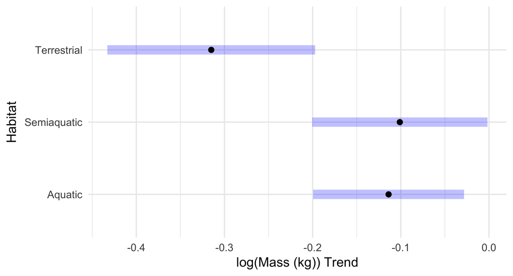

```r
plot(slope_comparison$emtrends) +
  labs(x = "log(Mass (kg)) Trend", y = "Habitat")
```

The top part of the output gives a slope for each habitat with CIs. The lower “contrasts” part is where we’ll focus now: it gives the p-values for the tests comparing each pair of habitats.

We have moderate evidence that terrestrial habitats are different from the others. But we have no evidence that the slopes are different between aquatic and semiaquatic.

## Model Predictions

### Predictions by Habitat (and Location)

For the prediction plots shown below, the other predictors in the model but not shown in the plot were held fixed at the following values:

- activity level: 1
- location: water for aquatic, air for terrestrial, both for semiaquatic

We also add in data from previous studies by Mortola and He for comparison.

```r
mortola <- read_excel('data/additional-species.xlsx',
                              sheet = 'mortola') |>
  mutate(log_Mb = log10(`Body mass`),
         body_mass = `Body mass`,
         log_fr = log10(fr),
         breath_rate = fr,
         common_name = species,
         across(c(common_name, habitat), str_to_title))

  he <- read_excel('data/additional-species.xlsx',
                              sheet = 'He') |>

  rename(log_Mb = `Log of Mass`,
         body_mass = `Mass (kg)`,
         breath_rate = `Breathing Frequency (br/min)`
         ) |>
  mutate(log_fr = log10(breath_rate),
         common_name = `Common Name`,
         across(c(common_name, habitat), str_to_title))
```

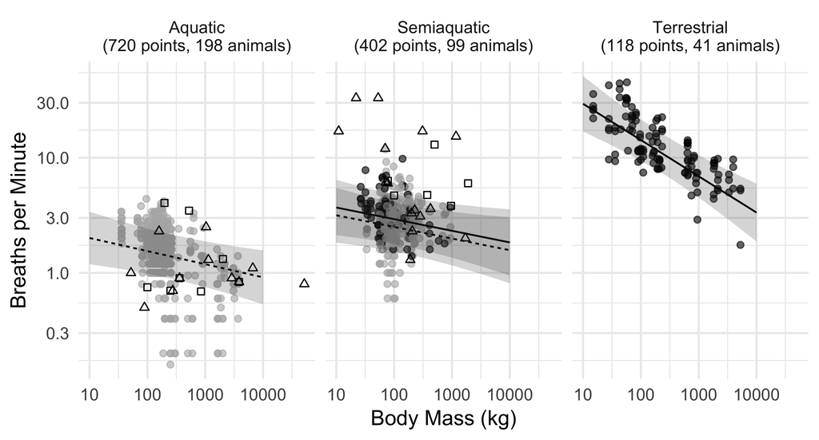

```r
colrs <- c('black', 'grey70')
log_preds <- ggpredict(breath_model,
                           terms = c('log_Mb', 'habitat', 'location'),
                           condition = c(activity_level = 1))

log_preds <- log_preds |>
  filter((facet == 'Air' & group %in% c('Terrestrial', 'Semiaquatic')) |
          (facet == 'Water' & group %in% c('Aquatic', 'Semiaquatic')))

individs_by_habitat <- breath_data |>
  select(log_fr, log_Mb, habitat, activity_level, temp, location,
         order, family, genus, species, individual_name,) |>
  drop_na() |>
  group_by(order, family, genus, species, individual_name, habitat) |>
  summarize(individual_name = first(individual_name)) |>
  ungroup() |>
  group_by(habitat) |>
  summarize(n_individs = n())

measurements_by_habitat <- breath_data |>
  select(log_fr, log_Mb, habitat, activity_level, temp, location,
         order, family, genus, species, individual_name,) |>
  drop_na() |>
  group_by(habitat) |>
  summarize(n_measurements = n())

habitat_labs <- paste0(levels(breath_data$habitat),
                       '\n(',
                       measurements_by_habitat$n_measurements,
                       ' points, ',
                       individs_by_habitat$n_individs,
                       ' animals)')
names(habitat_labs) <- levels(breath_data$habitat)

natural_preds <- data.frame(mass = 10^log_preds$x,
                            breaths = 10^log_preds$predicted,
                            conf_low = 10^log_preds$conf.low,
                            conf_hi = 10^log_preds$conf.high,
                            habitat = log_preds$group,
                            location = log_preds$facet
                            )
# plot data
gf_point(breath_rate ~ body_mass, color = ~location,
         data = breath_data,
         alpha = 0.6
         ) |>
  gf_facet_grid(~habitat ,
                labeller = labeller(habitat = habitat_labs)
                ) |>
  # with log scales on both axes
  gf_refine(scale_x_log10(), scale_y_log10(),
            scale_color_manual("", values = colrs)) |>
  gf_labs(x = 'Body Mass (kg)',
          y = 'Breaths per Minute') |>
  # add in He species -- open squares
  gf_point(breath_rate ~ body_mass | habitat,
          # inherit = FALSE,
           data = he,
           color = 'black',
           label = ~common_name,
           shape = 0) |> # 15) |>
  # add in Mortola species -- open triangles
  gf_point(breath_rate ~ body_mass | habitat,
         #  inherit = FALSE,
           data = mortola,
           color = 'black',
           label = ~common_name,
           shape = 2) |> #17) |>
  # add the predictions now
  gf_line(breaths ~ mass,
          linetype = ~location,
          data = natural_preds,
    inherit = FALSE) |>
  gf_facet_grid(~habitat ,
                 labeller = labeller(habitat = habitat_labs)
                ) |>
  gf_ribbon(conf_low + conf_hi ~ mass | habitat,
            linetype = ~location,
            # fill = ~location,
            data = natural_preds,
            inherit = FALSE,
            alpha = 0.2) |>
  gf_facet_grid(~habitat ,
                labeller = labeller(habitat = habitat_labs)
               ) |>
  gf_refine(guides(color = 'none', linetype = 'none'))
```

Open squares are data points from He et al. Open triangles are data points from Mortola et al. Grey data points are taken in water, and black ones in air. Lines and ribbons show model predictions, with the solid lines indicating measurements on land and dotted lines in water.

### Predictions by Habitat (and Location) - Interactive Version

```r
breath_data <- breath_data |>
  mutate(individual_info = paste0(individual_name,
                                  ' (', common_name, ', ',
                                  genus, ' ', species, ')'))

gf_point(breath_rate ~ body_mass | habitat, data = breath_data,
         alpha = 0.3, label = ~individual_info, color = ~order) |>
  # with log scales on both axes
  gf_refine(scale_x_log10(), scale_y_log10()) |>
  gf_labs(x = 'Body Mass (kg)',
          y = 'Breaths per Minute') |>
  # add the predictions now
  gf_line(breaths ~ mass | habitat,
          linetype = ~location,
          data = natural_preds,
    inherit = FALSE) |>
  gf_ribbon(conf_low + conf_hi ~ mass | habitat,
            linetype = ~location,
            data = natural_preds,
            inherit = FALSE) |>
  # add in He species -- grey squares
  gf_point(breath_rate ~ body_mass | habitat,
           inherit = FALSE,
           data = he,
           color = 'grey44',
           label = ~common_name,
           shape = 15) |>
  # add in Mortola species -- grey triangles
  gf_point(breath_rate ~ body_mass | habitat,
           inherit = FALSE,
           data = mortola,
           color = 'grey44',
           label = ~common_name,
           shape = 17) |>
  gf_refine(guides(linetype = "none")) |>
  ggplotly()
```

[interactive chart not shown]